# feedback_response

Group 3

3/20/2021

Your questions are in quotes. Our answers follow.

**“1. Biojtscore and BioJftotal are measuring the same (number of biocentric justifications the participant endorsed), the only difference is that the former was obtained from an open-ended question and the other from a close-ended question. Therefore, I think it would be better that they both have the same transformation into levels (e.g. level1=0,1,2; level2=3; level3=4), unless there was a mathematical reason to choose the levels.”**

We understand that `Biojtscore` and `BioJftotal` are similar, and we also tried the same level transformation (level1=0,1,2; level2=3; level3=4) to them. However, the result of `BioJftotal` shows that level 2 has 0 values in it, which means there is no value being predicted as 2.

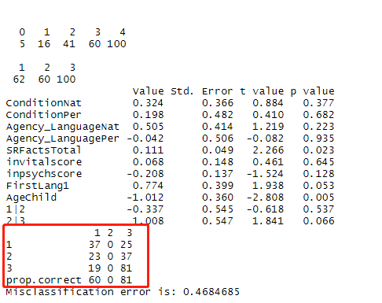

(BioJftotal Model Fit Result)

Level 2 is less meaningful in this case, and the model does not fit the data properly if we set the level transformation in this way. Thus, we switched the way of transforming `BioJftotal`.

And we have a question for you. Since `Biojtscore` and `BioJftotal` are so similar, do you think it is reasonable to combine them together into one dependent variable (e.g. `Bioscore` = `Biojtscore` + `BioJftotal`)?

**“2. Also, while I was looking at the results, I saw that children were more biocentric than adults but they were also more anthropocentric (both groups were able to provide more than one kind of justification for each situation). It seems that the two separate scores (Biojtscore and Antjtscore) don’t let us see differences between those participants who only provided biocentric justifications and those who provided both antrhopocentric and biocentric justifications (for instance, children could be providing more justifications of different kind than adults but we cannot assure that with this analysis). Do you think it would be a good idea to integrate both scores, what alternatives do you know to deal with this kind of issue? I was thinking that we could calculate the proportion of Biocentric justifications over the total amount of justifications (Biocentric+antrhopocentric). Are there any limitations to this approach?”**

It is hard to see the differences between individuals who provided both anthropocentric and biocentric justifications and who only provided one kind of justification by the barplot in the last report. Instead of applying the proportion method you mentioned and redoing the barplot, we created balloonplots for the Child group and Adult group separately.

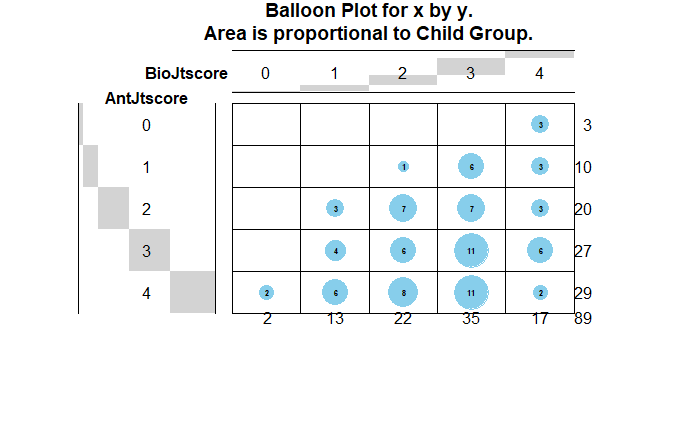

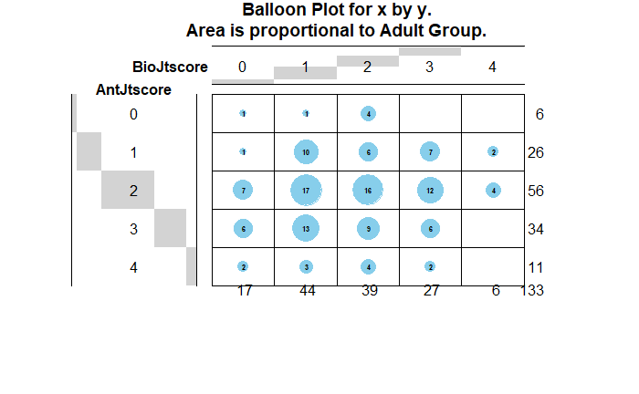

On the balloonplots, the vertical axis represents `AntJtscore` and the horizontal axis is `BioJtscore`. You may notice the gray region behind each level. The size of the shaded region corresponds to the total frequency of each level for that variable. For instance, in the Child group, most children get score 3 for `BioJtscore`, so the shaded region for `BioJtscore` level 3 is greater than that of the other levels. The size of each blue dot matches the number of individuals who get the corresponding scores for `BiojtScore` and `AntJtscore`, for example, in the Adult group, there are only two individuals get `BioJtscore` 0 and `AntJtscore` 4.

In such a way, we can find that children have higher frequency of getting `BioJtscore` in range [2,3] and `AntJtscore` in range [2,4], and adults have higher frequency of getting `BioJtscore` in range [1,3] and `AntJtscore` in range [1,3]. To be specific, the Child group gets the highest frequency for `BioJtscore` at level 3 and `AntJtscore` at level 4 (`AntJtscore` 4 and 3 are close, level 4 only has two more individuals than level 3), which indicates children tend to get high score for both kinds of justifications. Meanwhile, the adult group gets the highest frequency for `BioJtscore` at level 1 and `AntJtscore` at level 2, which implies most of them do not have strong attitude for both kinds of justifications.

Please let us know if this is still not clear.

**“3.You mentioned the possibility to do a Principal component analysis, how this could work? Can you explain more about it? Would it group agency language and condition as a factor?”**

We did look into Principal Component Analysis (PCA) for your predictor variables. PCA is a way to construct new variables, “principal components”, to represent several variables. PCA is mostly used in situations where there are a multitude of variables that can be combined into a smaller and more understandable set of variables (your data set does not suffer from a problem of a multitude of predictor variables). PCA is sometimes used for predictor variables that are correlated. But PCA is only used for continuous variables. And as such, we could not combined `Condition` and `Agency_Language`, and we’ve continued to run the models using just `Condition` (leaving `Agency_Language` out of the model).

We then tried the linear model fit three ways. (1) Using both the `invitalscore` and `inpsychscore` in the model. (NOTE: We used the “normalized”, not the “compressed” method for combining the adult and children’s `invitalscore` and `inpsychscore` variables.) (2) By combining the two scores into a new variable `postqs` = `invitalscore` + `inpsychscore`. (3) By doing principal component analysis to combine `invitalscore` and `inpsychscore` into a new variable, `postpca`.

As you can see in the summary of the model fits, there is no difference in the $Adjusted.R^2$. And we’ve concluded that the choice of what to do with the phase 3 questionnaire comes down to what makes the most sense in the context of your experiment. Since `invitalscore` and `inpsychscore` are correlated we would suggest looking at the seventeen questions that were asked in the post questionnaire to see if it makes sense to combine them into one variable. Or if it makes to keep these as two separate variables, we can continue to do that.

```
Call:
lm(formula = MeanSever ~ Condition + SRFactsTotal + invitalscore +
    inpsychscore + FirstLang + Age, data = AC_df)

Residuals:
     Min       1Q   Median       3Q      Max
-1.68513 -0.44849  0.01683  0.41194  1.42652

Coefficients:
              Estimate Std. Error t value Pr(>|t|)
(Intercept)   1.623603   0.182912   8.876 2.81e-16 ***
ConditionNat  0.060888   0.109228   0.557   0.5778
ConditionPer  0.075715   0.111191   0.681   0.4966
SRFactsTotal  0.019409   0.015928   1.219   0.2243
invitalscore  0.001812   0.182530   0.010   0.9921
inpsychscore  0.036534   0.156307   0.234   0.8154
FirstLang1   -0.286629   0.136141  -2.105   0.0364 *
AgeChild      0.717942   0.134497   5.338 2.39e-07 ***
---
Signif. codes:  0 '***' 0.001 '**' 0.01 '*' 0.05 '.' 0.1 ' ' 1

Residual standard error: 0.6612 on 214 degrees of freedom
Multiple R-squared:  0.1969,    Adjusted R-squared:  0.1706
F-statistic: 7.494 on 7 and 214 DF,  p-value: 4.551e-08
```

```
Call:
lm(formula = MeanSever ~ Condition + SRFactsTotal + postqs +
    FirstLang + Age, data = AC_df)

Residuals:
     Min       1Q   Median       3Q      Max
-1.69202 -0.44600  0.01459  0.41722  1.42268

Coefficients:
             Estimate Std. Error t value Pr(>|t|)
(Intercept)   1.59740    0.18291   8.733 7.01e-16 ***
ConditionNat  0.05914    0.10894   0.543   0.5878
ConditionPer  0.07321    0.11011   0.665   0.5068
SRFactsTotal  0.01949    0.01583   1.232   0.2195
postqs        0.08651    0.17163   0.504   0.6147
FirstLang1   -0.28637    0.13559  -2.112   0.0358 *
AgeChild      0.72821    0.10643   6.842 7.99e-11 ***
---
Signif. codes:  0 '***' 0.001 '**' 0.01 '*' 0.05 '.' 0.1 ' ' 1

Residual standard error: 0.6594 on 215 degrees of freedom
Multiple R-squared:  0.1975,    Adjusted R-squared:  0.1751
F-statistic: 8.819 on 6 and 215 DF,  p-value: 1.333e-08
```

```
Call:
lm(formula = MeanSever ~ Condition + SRFactsTotal + postpca +
    FirstLang + Age, data = AC_df)

Residuals:
     Min       1Q   Median       3Q      Max
-1.68055 -0.44268  0.01771  0.41462  1.43161

Coefficients:
              Estimate Std. Error t value Pr(>|t|)
(Intercept)   1.666554   0.189025   8.817 4.07e-16 ***
ConditionNat  0.061168   0.108959   0.561   0.5751
ConditionPer  0.077673   0.110040   0.706   0.4810
SRFactsTotal  0.019215   0.015830   1.214   0.2261
postpca      -0.009992   0.039490  -0.253   0.8005
FirstLang1   -0.287664   0.135626  -2.121   0.0351 *
AgeChild      0.729131   0.107378   6.790 1.08e-10 ***
---
Signif. codes:  0 '***' 0.001 '**' 0.01 '*' 0.05 '.' 0.1 ' ' 1

Residual standard error: 0.6597 on 215 degrees of freedom
Multiple R-squared:  0.1968,    Adjusted R-squared:  0.1744
F-statistic:  8.78 on 6 and 215 DF,  p-value: 1.455e-08
```

**“4. Regarding the Anova test, I saw that the model with age was significantly different than the model without it which is interesting. However, I’m not sure I’m interpreting the results in a right way, is this Anova comparing the between group variances (children vs. adults) with the within group variances for each dependent variable? Can you please describe more those results?”**

Take this result as an example. Because these two models differ in the use of the age (both models use same predictors except age), this ANVOA will test whether or not including the age leads to a significant improvement:

|  | Res.Df | RSS | Df | Sum of Sq | F | Pr(>F) |
| --- | --- | --- | --- | --- | --- | --- |
| 1 | 215 | 106.01818 | NA | NA | NA | NA |
| 2 | 214 | 93.56058 | 1 | 12.45759 | 28.49411 | 2.390375e-07 |

As you can see, the result shows a Df of 1 (indicating that the more complex model has one additional parameter), and a very small p-value (< .001). This means that adding the age to the model did lead to a significantly improved fit over the model 1. Moreover, the RSS (residual sum of squares) has been decreased a lot, which is good.  
You can also look at this website: https://bookdown.org/ndphillips/YaRrr/comparing-regression-models-with-anova.html if you are interested in ANOVA test.

**“5. Check whether the analysis show similar results when taking the dependent variables as continous”**

We want to make sure that taking the dependent variables as continuous, especially the Meansever, is valid before we discuss the results from the multiple linear regression. Otherwise it would be unhelpful.

This is the residual plot from the multiple linear regression:

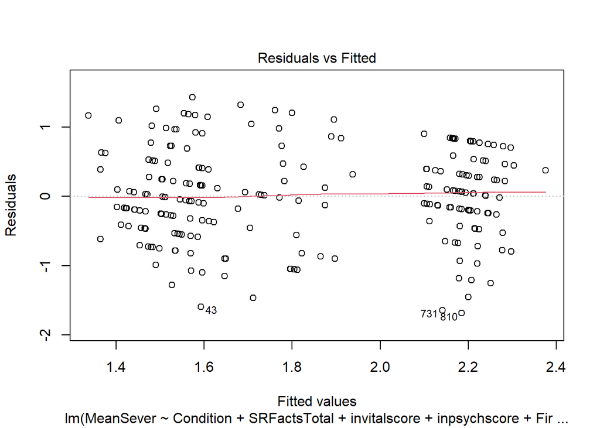

```r
multi_linear <- lm(MeanSever ~  Condition + SRFactsTotal + invitalscore  + inpsychscore + FirstLang + Age, data = AC_df)
plot(multi_linear, which = 1)
```

The parallel lines indicate that our dependent variables only have several distinct possible values, this violates the assumption of linearity. This is also why we considered to level the data and switch to the ordinal regression.

As the linear regression is not appropriate for our data, we should not trust the result from it.

5.2 BioJscore/AntJscore/BioJFtotal

Since these three dependent variables are categorical, it is not recommended to treat them as continuous variables.(We took these three dependent variables as continious and fitted linear models last semester,but they did not fit well).